# Сборный проект

Заказчик проекта: Интернет магазин по продаже компьютерных игр "Стримчик".

Задача проекта: подготовить и исследованить данные по продажам игровых платформ за данный период, выявить определяющие успешность игры закономерности с целью прогноза потенциально популярного продукта и планирования рекламной кампании на 2017 год.

Импортируем необходимые библиотеки:

```python
import pandas as pd
import numpy as np
import matplotlib.patches as patches
import matplotlib.pyplot as plt
import seaborn as sns
from scipy import stats as st
import warnings
```

# 1. Общая информация по данным

```python
data = pd.read_csv('/datasets/games.csv')
```

```python
#Общая информация

print('Общая информация:')

display(data.info())

print(30*' =')

#Вывод первых пяти строк

print('Первые пять строк датафрейма:')

display(data.head())

print(30*' =')

print('Название столбцов датафрейма:')

print(f'Название столбцов: {list(data.columns)}')

print(30*' =')

#Пропуски

print('Информация о пропусках:')

display(data.isnull().sum())

print(30*' =')

#Полные дубликаты

print(f'Полных дубликатов: {data.duplicated().sum()}')

print(30*' =')
```

```
Общая информация:
<class 'pandas.core.frame.DataFrame'>
RangeIndex: 16715 entries, 0 to 16714
Data columns (total 11 columns):
 #   Column           Non-Null Count  Dtype
---  ------           --------------  -----
 0   Name             16713 non-null  object
 1   Platform         16715 non-null  object
 2   Year_of_Release  16446 non-null  float64
 3   Genre            16713 non-null  object
 4   NA_sales         16715 non-null  float64
 5   EU_sales         16715 non-null  float64
 6   JP_sales         16715 non-null  float64
 7   Other_sales      16715 non-null  float64
 8   Critic_Score     8137 non-null   float64
 9   User_Score       10014 non-null  object
 10  Rating           9949 non-null   object
dtypes: float64(6), object(5)
memory usage: 1.4+ MB
```

```
None
```

```
 = = = = = = = = = = = = = = = = = = = = = = = = = = = = = =
Первые пять строк датафрейма:
```

|  | Name | Platform | Year_of_Release | Genre | NA_sales | EU_sales | JP_sales | Other_sales | Critic_Score | User_Score | Rating |
| --- | --- | --- | --- | --- | --- | --- | --- | --- | --- | --- | --- |
| 0 | Wii Sports | Wii | 2006.0 | Sports | 41.36 | 28.96 | 3.77 | 8.45 | 76.0 | 8 | E |
| 1 | Super Mario Bros. | NES | 1985.0 | Platform | 29.08 | 3.58 | 6.81 | 0.77 | NaN | NaN | NaN |
| 2 | Mario Kart Wii | Wii | 2008.0 | Racing | 15.68 | 12.76 | 3.79 | 3.29 | 82.0 | 8.3 | E |
| 3 | Wii Sports Resort | Wii | 2009.0 | Sports | 15.61 | 10.93 | 3.28 | 2.95 | 80.0 | 8 | E |
| 4 | Pokemon Red/Pokemon Blue | GB | 1996.0 | Role-Playing | 11.27 | 8.89 | 10.22 | 1.00 | NaN | NaN | NaN |

```
 = = = = = = = = = = = = = = = = = = = = = = = = = = = = = =
Название столбцов датафрейма:
Название столбцов: ['Name', 'Platform', 'Year_of_Release', 'Genre', 'NA_sales', 'EU_sales', 'JP_sales', 'Other_sales', 'Critic_Score', 'User_Score', 'Rating']
 = = = = = = = = = = = = = = = = = = = = = = = = = = = = = =
Информация о пропусках:
```

```
Name                  2
Platform              0
Year_of_Release     269
Genre                 2
NA_sales              0
EU_sales              0
JP_sales              0
Other_sales           0
Critic_Score       8578
User_Score         6701
Rating             6766
dtype: int64
```

```
 = = = = = = = = = = = = = = = = = = = = = = = = = = = = = =
Полных дубликатов: 0
 = = = = = = = = = = = = = = = = = = = = = = = = = = = = = =
```

# 2. Подготовка данных

- Приводим название столбцов к нижнему регистру, преобразуем некоторые данные к нужному типу:

```python
data = data.rename(columns = {'Name':'name','Platform':'platform', 'Year_of_Release':'year_of_release', \
                              'Genre':'genre', 'NA_sales':'na_sales', 'EU_sales':'eu_sales', 'JP_sales':'jp_sales',\
                             'Other_sales':'other_sales', 'Critic_Score':'critic_score',\
                             'User_Score':'user_score', 'Rating':'rating'})
display(data.head())
```

|  | name | platform | year_of_release | genre | na_sales | eu_sales | jp_sales | other_sales | critic_score | user_score | rating |
| --- | --- | --- | --- | --- | --- | --- | --- | --- | --- | --- | --- |
| 0 | Wii Sports | Wii | 2006.0 | Sports | 41.36 | 28.96 | 3.77 | 8.45 | 76.0 | 8 | E |
| 1 | Super Mario Bros. | NES | 1985.0 | Platform | 29.08 | 3.58 | 6.81 | 0.77 | NaN | NaN | NaN |
| 2 | Mario Kart Wii | Wii | 2008.0 | Racing | 15.68 | 12.76 | 3.79 | 3.29 | 82.0 | 8.3 | E |
| 3 | Wii Sports Resort | Wii | 2009.0 | Sports | 15.61 | 10.93 | 3.28 | 2.95 | 80.0 | 8 | E |
| 4 | Pokemon Red/Pokemon Blue | GB | 1996.0 | Role-Playing | 11.27 | 8.89 | 10.22 | 1.00 | NaN | NaN | NaN |

```python
# меняем значение tbd на NaN и далее тип столбца на float
data['user_score'].value_counts()
data= data.replace({'user_score':{'tbd' : 'NaN'}})
data = data.astype({'user_score': np.float64})

data['user_score'].value_counts()
display(data.head())
data.info()
```

|  | name | platform | year_of_release | genre | na_sales | eu_sales | jp_sales | other_sales | critic_score | user_score | rating |
| --- | --- | --- | --- | --- | --- | --- | --- | --- | --- | --- | --- |
| 0 | Wii Sports | Wii | 2006.0 | Sports | 41.36 | 28.96 | 3.77 | 8.45 | 76.0 | 8.0 | E |
| 1 | Super Mario Bros. | NES | 1985.0 | Platform | 29.08 | 3.58 | 6.81 | 0.77 | NaN | NaN | NaN |
| 2 | Mario Kart Wii | Wii | 2008.0 | Racing | 15.68 | 12.76 | 3.79 | 3.29 | 82.0 | 8.3 | E |
| 3 | Wii Sports Resort | Wii | 2009.0 | Sports | 15.61 | 10.93 | 3.28 | 2.95 | 80.0 | 8.0 | E |
| 4 | Pokemon Red/Pokemon Blue | GB | 1996.0 | Role-Playing | 11.27 | 8.89 | 10.22 | 1.00 | NaN | NaN | NaN |

```
<class 'pandas.core.frame.DataFrame'>
RangeIndex: 16715 entries, 0 to 16714
Data columns (total 11 columns):
 #   Column           Non-Null Count  Dtype
---  ------           --------------  -----
 0   name             16713 non-null  object
 1   platform         16715 non-null  object
 2   year_of_release  16446 non-null  float64
 3   genre            16713 non-null  object
 4   na_sales         16715 non-null  float64
 5   eu_sales         16715 non-null  float64
 6   jp_sales         16715 non-null  float64
 7   other_sales      16715 non-null  float64
 8   critic_score     8137 non-null   float64
 9   user_score       7590 non-null   float64
 10  rating           9949 non-null   object
dtypes: float64(7), object(4)
memory usage: 1.4+ MB
```

```python
# заменяем занчения Nan на UnKn - Unknown в столбце  rating
data['rating'] = data['rating'].fillna('UnKn')
display(data.head())

#display(data.info())
#data.value_counts()
```

|  | name | platform | year_of_release | genre | na_sales | eu_sales | jp_sales | other_sales | critic_score | user_score | rating |
| --- | --- | --- | --- | --- | --- | --- | --- | --- | --- | --- | --- |
| 0 | Wii Sports | Wii | 2006.0 | Sports | 41.36 | 28.96 | 3.77 | 8.45 | 76.0 | 8.0 | E |
| 1 | Super Mario Bros. | NES | 1985.0 | Platform | 29.08 | 3.58 | 6.81 | 0.77 | NaN | NaN | UnKn |
| 2 | Mario Kart Wii | Wii | 2008.0 | Racing | 15.68 | 12.76 | 3.79 | 3.29 | 82.0 | 8.3 | E |
| 3 | Wii Sports Resort | Wii | 2009.0 | Sports | 15.61 | 10.93 | 3.28 | 2.95 | 80.0 | 8.0 | E |
| 4 | Pokemon Red/Pokemon Blue | GB | 1996.0 | Role-Playing | 11.27 | 8.89 | 10.22 | 1.00 | NaN | NaN | UnKn |

```python
#  заменяем пропуски в значенияж critic_score медианным значением:
#critic_score_mean=data.critic_score.mean()
#data['critic_score'] = data['critic_score'].fillna( value= critic_score_mean)
#display(critic_score_med)
```

```python
# заменяем пропуски в значениях user_score
#user_score_mean= data.user_score.median()
#data['user_score'] = data['user_score'].fillna(value= user_score_mean)
#display(user_score_med)
```

```python
data.info()
```

```
<class 'pandas.core.frame.DataFrame'>
RangeIndex: 16715 entries, 0 to 16714
Data columns (total 11 columns):
 #   Column           Non-Null Count  Dtype
---  ------           --------------  -----
 0   name             16713 non-null  object
 1   platform         16715 non-null  object
 2   year_of_release  16446 non-null  float64
 3   genre            16713 non-null  object
 4   na_sales         16715 non-null  float64
 5   eu_sales         16715 non-null  float64
 6   jp_sales         16715 non-null  float64
 7   other_sales      16715 non-null  float64
 8   critic_score     8137 non-null   float64
 9   user_score       7590 non-null   float64
 10  rating           16715 non-null  object
dtypes: float64(7), object(4)
memory usage: 1.4+ MB
```

```python
# создаем столбец с суммой продаж по всем регионам и передаем в него данные:
data['total_sales'] = data['na_sales'] + data['eu_sales'] + data['jp_sales'] + data['other_sales']

display(data.head())
```

|  | name | platform | year_of_release | genre | na_sales | eu_sales | jp_sales | other_sales | critic_score | user_score | rating | total_sales |
| --- | --- | --- | --- | --- | --- | --- | --- | --- | --- | --- | --- | --- |
| 0 | Wii Sports | Wii | 2006.0 | Sports | 41.36 | 28.96 | 3.77 | 8.45 | 76.0 | 8.0 | E | 82.54 |
| 1 | Super Mario Bros. | NES | 1985.0 | Platform | 29.08 | 3.58 | 6.81 | 0.77 | NaN | NaN | UnKn | 40.24 |
| 2 | Mario Kart Wii | Wii | 2008.0 | Racing | 15.68 | 12.76 | 3.79 | 3.29 | 82.0 | 8.3 | E | 35.52 |
| 3 | Wii Sports Resort | Wii | 2009.0 | Sports | 15.61 | 10.93 | 3.28 | 2.95 | 80.0 | 8.0 | E | 32.77 |
| 4 | Pokemon Red/Pokemon Blue | GB | 1996.0 | Role-Playing | 11.27 | 8.89 | 10.22 | 1.00 | NaN | NaN | UnKn | 31.38 |

# 3.1. Исследование данных

```python
games_per_year =data.pivot_table(index='year_of_release', values = 'total_sales', aggfunc ='count') # код исправлен
display(games_per_year.head())
```

| year_of_release | total_sales |
| --- | --- |
| 1980.0 | 9 |
| 1981.0 | 46 |
| 1982.0 | 36 |
| 1983.0 | 17 |
| 1984.0 | 14 |

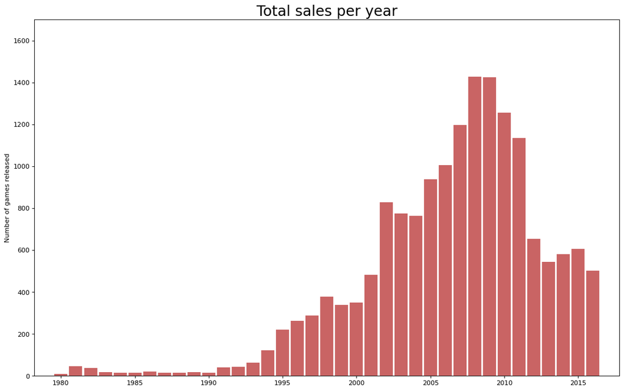

```python
# строим диаграмму
fig, ax = plt.subplots(figsize=(16,10), facecolor='white', dpi= 80)
ax.vlines(x=games_per_year.index, ymin=0, ymax=games_per_year.values, color='firebrick', alpha=0.7, linewidth=20);

ax.set_title('Total sales per year', fontdict={'size':22});
ax.set(ylabel='Number of games released', ylim=(0, 1700));
```

Вывод: Рост выпуска игр приходится на 2000 - 2010 года

# 3.2 Находим изменения продаж по платформам, строим распределения по годам для ТОП-5 платформ

```python
display(data.query('platform == "PS4"').head())
```

|  | name | platform | year_of_release | genre | na_sales | eu_sales | jp_sales | other_sales | critic_score | user_score | rating | total_sales |
| --- | --- | --- | --- | --- | --- | --- | --- | --- | --- | --- | --- | --- |
| 31 | Call of Duty: Black Ops 3 | PS4 | 2015.0 | Shooter | 6.03 | 5.86 | 0.36 | 2.38 | NaN | NaN | UnKn | 14.63 |
| 42 | Grand Theft Auto V | PS4 | 2014.0 | Action | 3.96 | 6.31 | 0.38 | 1.97 | 97.0 | 8.3 | M | 12.62 |
| 77 | FIFA 16 | PS4 | 2015.0 | Sports | 1.12 | 6.12 | 0.06 | 1.28 | 82.0 | 4.3 | E | 8.58 |
| 87 | Star Wars Battlefront (2015) | PS4 | 2015.0 | Shooter | 2.99 | 3.49 | 0.22 | 1.28 | NaN | NaN | UnKn | 7.98 |
| 92 | Call of Duty: Advanced Warfare | PS4 | 2014.0 | Shooter | 2.81 | 3.48 | 0.14 | 1.23 | 83.0 | 5.7 | M | 7.66 |

| platform | total_sales |
| --- | --- |
| PS2 | 1255.77 |
| X360 | 971.42 |
| PS3 | 939.65 |
| Wii | 907.51 |
| DS | 806.12 |

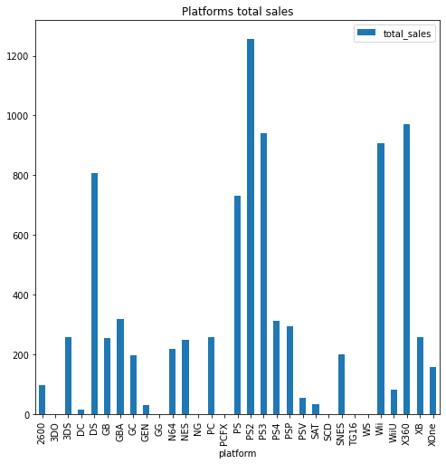

```python
platform_sales = data.pivot_table(index= ['platform'], values= 'total_sales',  aggfunc= 'sum')

#sorted_p = platform_sales.groupby('total_sales').sum().reset_index()
sorted_p = platform_sales.sort_values(by='total_sales', ascending=False)

#grouped = df.groupby('mygroups').sum().reset_index()
#grouped.sort_values('mygroups', ascending=False)

display(sorted_p.head(5))
#display(platform_sales.head(5))

#df = df_raw.groupby('class').size()

# Make the plot with pandas
platform_sales.plot(kind='bar', subplots=True, figsize=(8, 8))
plt.title("Platforms total sales")
plt.ylabel("")
plt.show()
```

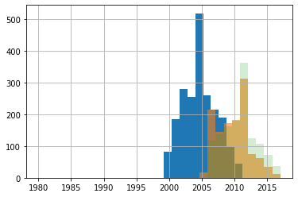

```python
# общая гистограммы по годам для Топ-3 платформ

ps_2= data[data['platform'] == 'PS2']['year_of_release']
ps_2.hist(bins=30, range=(1980, 2016 ), alpha = 1.0)

x_360= data[data['platform'] == 'X360']['year_of_release']
x_360.hist(bins=30, range=(1980, 2017 ), alpha = 0.6)

ps_3= data[data['platform'] == 'PS3']['year_of_release']
ps_3.hist(bins=30, range=(1980, 2017 ), alpha = 0.2) ;
```

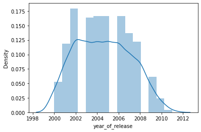

```python
# строим распределение для самой успешной платформы PS2
sns_plot = sns.distplot(data[data['platform']=='PS2']['year_of_release'])
fig = sns_plot.get_figure()
warnings.filterwarnings("ignore")
```

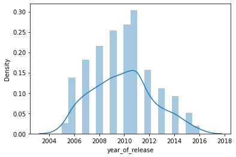

```python
# строим распределение для второй платформы X360
sns_plot = sns.distplot(data[data['platform']=='X360']['year_of_release'])
fig = sns_plot.get_figure()
warnings.filterwarnings("ignore")
```

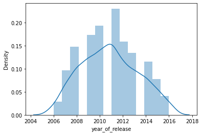

```python
# строим распределение для третьей платформы PS3
sns_plot = sns.distplot(data[data['platform']=='PS3']['year_of_release'])
fig = sns_plot.get_figure()
warnings.filterwarnings("ignore")
```

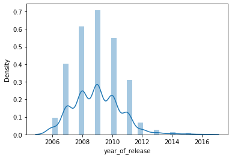

```python
# строим распределение для чеивретой Wii
sns_plot = sns.distplot(data[data['platform']=='Wii']['year_of_release'])
fig = sns_plot.get_figure()
```

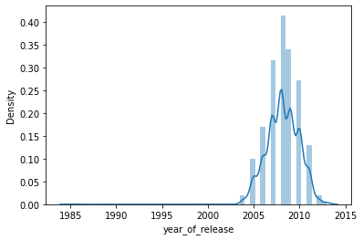

```python
# строим распределение для пятой платформы из наиболее успешных  - DS
sns_plot = sns.distplot(data[data['platform']=='DS']['year_of_release'])
fig = sns_plot.get_figure()
```

Вывод: средний цикл активных продаж платформ - 10 лет, пик плотности распределения приходится на 5й год, после чего как правило наступает спад продаж и на 10й год платформа либо преестает существовать либо трансофрмируется в новую платформу с другим названием

Поскольку средний цикл жизни платформы 10 лет и пик раста продаж приходится на 5й год, необходимо изучить новые платформы появившиеся за последние 5 лет для прогноза потенциально прибыльных платформ

# 3.3 Делаем срез данных по выпуску и продажам игр начиная с 2014 года. Обозначаем его как - "Актуальный период" и далее используем Data Frame в таком виде.

```python
# делаем срез по выпуску игр за 2014-2016 годы
data_new = data.query('year_of_release in (2014.0, 2015.0, 2016.0)')

display(data_new.head())
```

|  | name | platform | year_of_release | genre | na_sales | eu_sales | jp_sales | other_sales | critic_score | user_score | rating | total_sales |
| --- | --- | --- | --- | --- | --- | --- | --- | --- | --- | --- | --- | --- |
| 31 | Call of Duty: Black Ops 3 | PS4 | 2015.0 | Shooter | 6.03 | 5.86 | 0.36 | 2.38 | NaN | NaN | UnKn | 14.63 |
| 42 | Grand Theft Auto V | PS4 | 2014.0 | Action | 3.96 | 6.31 | 0.38 | 1.97 | 97.0 | 8.3 | M | 12.62 |
| 47 | Pokemon Omega Ruby/Pokemon Alpha Sapphire | 3DS | 2014.0 | Role-Playing | 4.35 | 3.49 | 3.10 | 0.74 | NaN | NaN | UnKn | 11.68 |
| 77 | FIFA 16 | PS4 | 2015.0 | Sports | 1.12 | 6.12 | 0.06 | 1.28 | 82.0 | 4.3 | E | 8.58 |
| 87 | Star Wars Battlefront (2015) | PS4 | 2015.0 | Shooter | 2.99 | 3.49 | 0.22 | 1.28 | NaN | NaN | UnKn | 7.98 |

```python
# Рассмотрим новые платформы, в которых игры созданны начиная с 2014 года:
data_new_year =data_new.pivot_table(index= 'platform', values= 'year_of_release' )
data_new_year =data_new_year.sort_values('year_of_release', ascending= False)


display(data_new_year.head(30))
```

| platform | year_of_release |
| --- | --- |
| PS4 | 2015.236702 |
| XOne | 2015.114035 |
| PC | 2015.046358 |
| PSV | 2014.949153 |
| 3DS | 2014.839623 |
| WiiU | 2014.767123 |
| PS3 | 2014.680365 |
| X360 | 2014.549550 |
| Wii | 2014.545455 |
| PSP | 2014.230769 |

Строим диаграмму по продажам платформ за период 2014-2016 годы

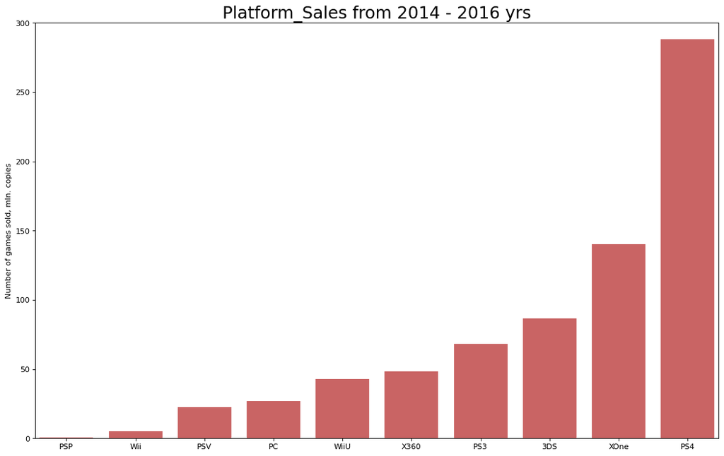

```python
data_sales = data_new.pivot_table(index= 'platform', values= 'total_sales', aggfunc= 'sum')
data_sales = data_sales.sort_values('total_sales', ascending=True)

fig, ax = plt.subplots(figsize=(16,10), facecolor='white', dpi= 80)
ax.vlines(x=data_sales.index, ymin=0, ymax=data_sales.values, color='firebrick', alpha=0.7, linewidth=70);

ax.set_title('Platform_Sales from 2014 - 2016 yrs', fontdict={'size':22});
ax.set(ylabel='Number of games sold, mln. copies', ylim=(0, 300));
```

Лидеры продаж за актуальный период 2014-2016 годы - платформы PS4, XOne, 3DS.

Строим гистограммы распределения по годам для новых платформ лидеров, выпуск начиная с 2014-15 годов

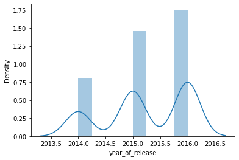

```python
#  платформа PS4
sns_plot = sns.distplot(data_new[data_new['platform']=='PS4']['year_of_release'])
fig = sns_plot.get_figure()
warnings.filterwarnings("ignore")
```

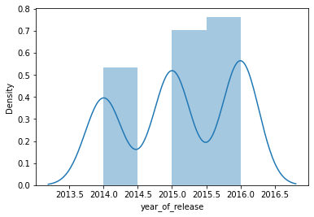

```python
#  платформа XOne
sns_plot = sns.distplot(data_new[data_new['platform']=='XOne']['year_of_release'])
fig = sns_plot.get_figure()
warnings.filterwarnings("ignore")
```

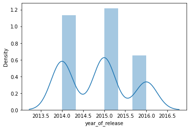

```python
#  платформа 3DS
sns_plot = sns.distplot(data_new[data_new['platform']=='3DS']['year_of_release'])
fig = sns_plot.get_figure()
warnings.filterwarnings("ignore")
```

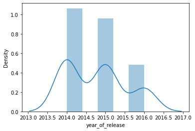

```python
#  платформа WiiU
sns_plot = sns.distplot(data_new[data_new['platform']=='WiiU']['year_of_release'])
fig = sns_plot.get_figure()
warnings.filterwarnings("ignore")
```

Лидеры продаж за 2014 -2016 года - платформы PS4, XOne, 3DS и WiiU. Платформы, демонстрирующие восходящую динамику за актуальный период - PS4 и XOne. Если мы предполагаем, что цикл фазы роста на рынке 5 лет, а также принимая во внимания успех предыдущих платформ данного производителя - мы можем сделать прогноз роста продаж в 2017 году. Платформы 3DS и WiiU имеют тенденцию на снижение, скорей всего пик продаж у этих платфом пройден. PS3 и X360 также вряд ли будeт пользоваться спросом поскольку им на смену пришла обновленные версии.

# 3.4 Изучаем данные по глобальным продажам. Строим диаграмму размаха по платформам за актуальный период

```python
platform_games=data_new.pivot_table(index= 'platform', values = 'total_sales', aggfunc= 'sum')

#display(platform_games.head(10))
```

| platform | total_sales |
| --- | --- |
| 3DS | 86.68 |
| PC | 27.05 |
| PS3 | 68.18 |
| PS4 | 288.15 |
| PSP | 0.36 |
| PSV | 22.40 |
| Wii | 5.07 |
| WiiU | 42.98 |
| X360 | 48.22 |
| XOne | 140.36 |

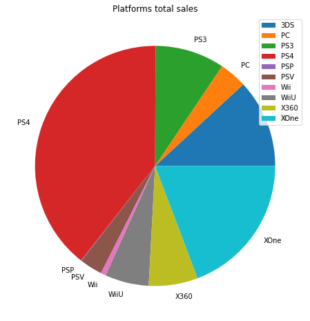

```python
display(platform_games.head(10))

platform_games.plot(kind='pie', subplots=True, figsize=(8, 8))
plt.title("Platforms total sales")
plt.ylabel("")
plt.show()
```

```python
platform_games.describe()
```

|  | total_sales |
| --- | --- |
| count | 10.000000 |
| mean | 72.945000 |
| std | 86.355404 |
| min | 0.360000 |
| 25% | 23.562500 |
| 50% | 45.600000 |
| 75% | 82.055000 |
| max | 288.150000 |

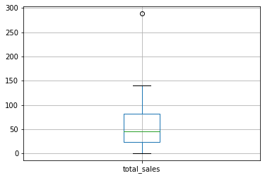

```python
platform_games.boxplot(column='total_sales')

plt.show()
```

Упорядоченный набор данных по продажам платформ: нижний квартиль - 23 млн. проданных копий, верхний квартиль - 82 млн. копий, медиана - 45 млн., выброс - 288 - на него стоит обратить внмание!

- Строим диаграмму размаха отдельных платформ за актуальный период

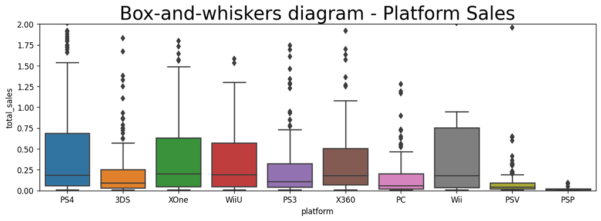

```python
plt.figure(figsize=(13,4), dpi= 120)
sns.boxplot(x='platform', y='total_sales', data=data_new, notch=False);

plt.title('Box-and-whiskers diagram - Platform Sales', fontsize=24)
plt.ylim(0, 2)
plt.show()
```

- Исследуем влияние отзывов критиков и пользователей на продажи на примере самой успешной платформы PS4 за актуальный период

```
Коэффициент Пирсона равен 0.328105086966363
```

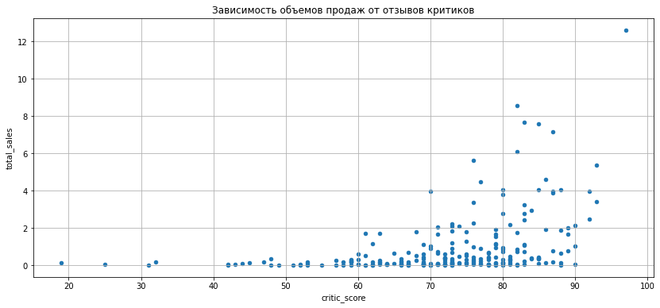

```python
#  строим диаграму рассения и исследуем зависимость между отзывами критиков и объемами продаж платформы PS4:
data_new.query('platform == "PS4"').plot(x = 'critic_score', y= 'total_sales', kind = 'scatter', sharex=False, grid=True,\
                                     alpha= 1.0, figsize=(14, 6) )
plt.title('Зависимость объемов продаж от отзывов критиков')

print('Коэффициент Пирсона равен', data_new['critic_score'].corr(data_new['total_sales']))
```

```
Коэффициент Пирсона равен -0.013070305002484585
```

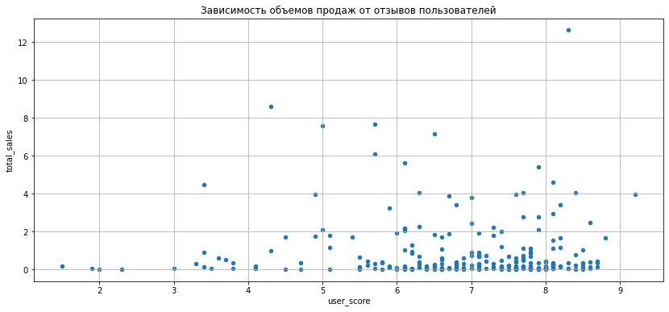

```python
#  строим диаграму рассения и исследуем зависимость между отзывами пользователей и объемами продаж платформы PS4:
data_new.query('platform == "PS4"').plot(x = 'user_score', y= 'total_sales', kind = 'scatter', sharex=False, grid=True,\
                                     alpha= 1.0, figsize=(14, 6) )
plt.title('Зависимость объемов продаж от отзывов пользователей')

print('Коэффициент Пирсона равен', data_new['user_score'].corr(data_new['total_sales']))
```

```
Коэффициент Пирсона равен 0.42867694370333226
```

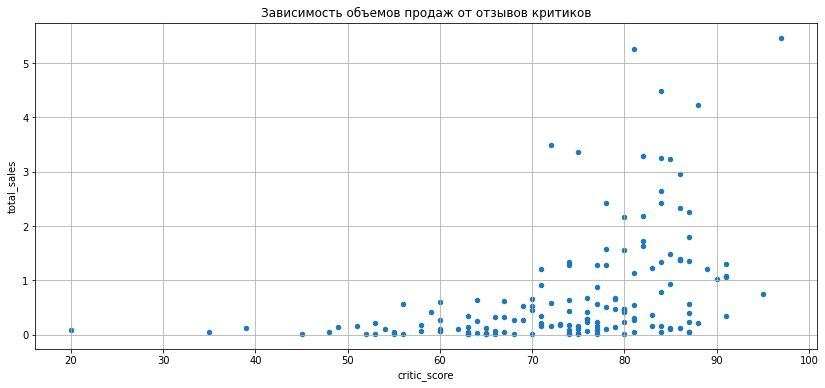

```python
#  строим диаграму рассения и исследуем зависимость между отзывами критиков и объемами продаж платформы XBox One:
data_new_xone = data_new.query('platform == "XOne"')

data_new_xone.plot(x = 'critic_score', y= 'total_sales', kind = 'scatter', sharex=False, grid=True,\
                                     alpha= 1.0, figsize=(14, 6) )
plt.title('Зависимость объемов продаж от отзывов критиков')

print('Коэффициент Пирсона равен', data_new_xone['critic_score'].corr(data_new_xone['total_sales']))
```

```
Коэффициент Пирсона равен -0.0703839280647581
```

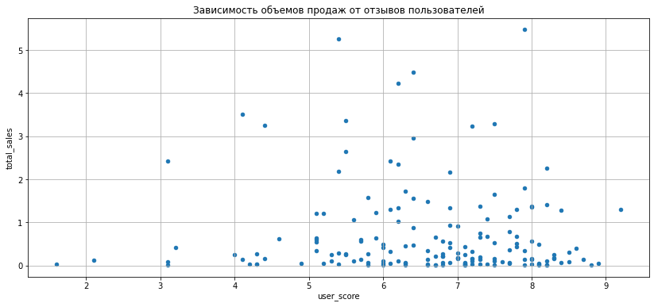

```python
#  строим диаграму рассения и исследуем зависимость между отзывами пользователей и объемами продаж платформы XOne:
data_new_xone = data_new.query('platform == "XOne"')

data_new_xone.plot(x = 'user_score', y= 'total_sales', kind = 'scatter', sharex=False, grid=True,\
                                     alpha= 1.0, figsize=(14, 6) )
plt.title('Зависимость объемов продаж от отзывов пользователей')

print('Коэффициент Пирсона равен', data_new_xone['user_score'].corr(data_new_xone['total_sales']))
```

Вывод: наблюдается зависимость обьема продаж XOne от мнения критиков и отсутсиве зависимости от мнения пользователей: Коэф Пирсона равен в одном случае 0.43 и 0 в другом.

```
Коэффициент Пирсона равен 0.314117492869051
```

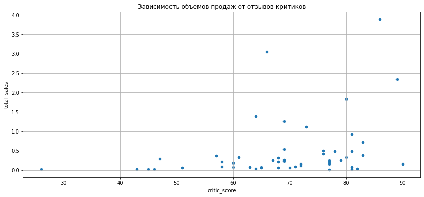

```python
#  строим диаграму рассения и исследуем зависимость между отзывами критиков и объемами продаж платформы 3DS:
data_new_ds = data_new.query('platform == "3DS"')

data_new_ds.plot(x = 'critic_score', y= 'total_sales', kind = 'scatter', sharex=False, grid=True,\
                                     alpha= 1.0, figsize=(14, 6) )
plt.title('Зависимость объемов продаж от отзывов критиков')

print('Коэффициент Пирсона равен', data_new_ds['critic_score'].corr(data_new_ds['total_sales']))
```

```
Коэффициент Пирсона равен 0.2151932718527028
```

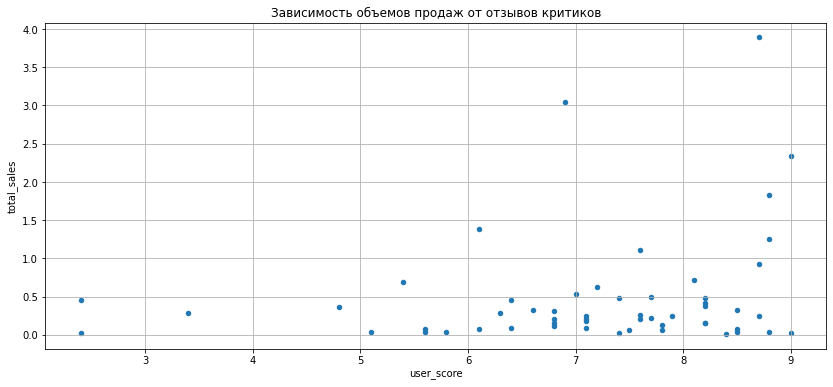

```python
#  строим диаграму рассения и исследуем зависимость между отзывами пользователей и объемами продаж платформы 3DS:
data_new_ds = data_new.query('platform == "3DS"')

data_new_ds.plot(x = 'user_score', y= 'total_sales', kind = 'scatter', sharex=False, grid=True,\
                                     alpha= 1.0, figsize=(14, 6) )
plt.title('Зависимость объемов продаж от отзывов критиков')

print('Коэффициент Пирсона равен', data_new_ds['user_score'].corr(data_new_ds['total_sales']))
```

У платформы 3DS существует средняя степень зависимости обьемов продаж от оценки критиков и пользователей: Коэф. Пирсона равен 0.31 и 0.22 соотвественно

# 3.4 Исследуем жанры и их влияние на объем продаж выпускаемых игр

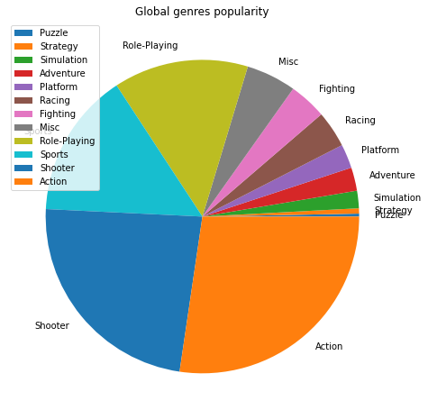

```python
genre = data_new.pivot_table(index= 'genre', values='total_sales', aggfunc='sum')
genre = genre.sort_values(by='total_sales', ascending=True)
#display(genre.head(12))

genre.plot(kind='pie', subplots=True, figsize=(8, 8))
plt.title("Global genres popularity")
plt.ylabel("")
plt.show()
```

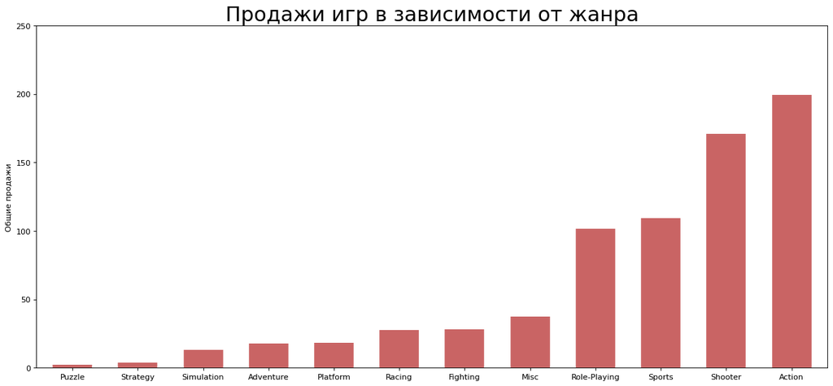

```python
# строим диаграмму, находим самые прибыльные жанры за акутальный период:
fig, ax = plt.subplots(figsize=(18,8), facecolor='white', dpi= 80)
ax.vlines(x=genre.index, ymin=0, ymax=genre.values, color='firebrick', alpha=0.7, linewidth=50);

ax.set_title('Продажи игр в зависимости от жанра', fontdict={'size':26});
ax.set(ylabel='Общие продажи', ylim=(0, 250));
```

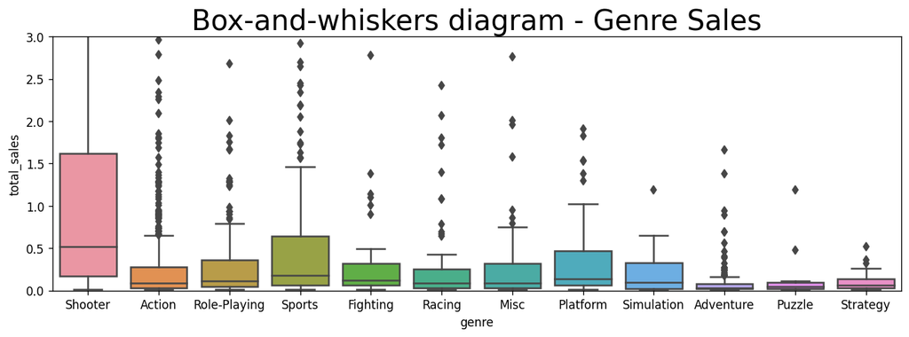

```python
# строим диаграмму размаха по жанрам:
plt.figure(figsize=(13,4), dpi= 120)
sns.boxplot(x='genre', y='total_sales', data=data_new, notch=False);

plt.title('Box-and-whiskers diagram - Genre Sales', fontsize=24)
plt.ylim(0, 3)
plt.show()
```

# 4. Составляем портрет пользователя каждого региона

```python
# данные за актуальный период
display(data_new.head())
```

|  | name | platform | year_of_release | genre | na_sales | eu_sales | jp_sales | other_sales | critic_score | user_score | rating | total_sales |
| --- | --- | --- | --- | --- | --- | --- | --- | --- | --- | --- | --- | --- |
| 31 | Call of Duty: Black Ops 3 | PS4 | 2015.0 | Shooter | 6.03 | 5.86 | 0.36 | 2.38 | NaN | NaN | UnKn | 14.63 |
| 42 | Grand Theft Auto V | PS4 | 2014.0 | Action | 3.96 | 6.31 | 0.38 | 1.97 | 97.0 | 8.3 | M | 12.62 |
| 47 | Pokemon Omega Ruby/Pokemon Alpha Sapphire | 3DS | 2014.0 | Role-Playing | 4.35 | 3.49 | 3.10 | 0.74 | NaN | NaN | UnKn | 11.68 |
| 77 | FIFA 16 | PS4 | 2015.0 | Sports | 1.12 | 6.12 | 0.06 | 1.28 | 82.0 | 4.3 | E | 8.58 |
| 87 | Star Wars Battlefront (2015) | PS4 | 2015.0 | Shooter | 2.99 | 3.49 | 0.22 | 1.28 | NaN | NaN | UnKn | 7.98 |

- Исследуем регион EU, находим наиболее популярные платформы, жанры, также смотрим влияет ли рейтинг на объемы продаж за актуальный период

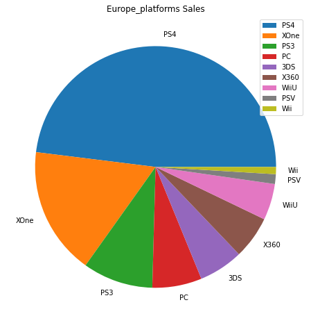

```python
# EU - самые популярные платформы
eu_platforms=data_new.pivot_table(index ='platform', values = 'eu_sales', aggfunc='sum')
eu_platforms=eu_platforms.sort_values(by='eu_sales', ascending=False)

eu_platforms.plot(kind='pie', subplots=True, figsize=(8, 8))
plt.title("Europe_platforms Sales")
plt.ylabel("")
plt.show()

#display(eu_platforms.head())
```

```python
# EU - саммые популярные жанры
eu_genre =data_new.pivot_table(index ='genre', values = 'eu_sales', aggfunc = 'sum')
eu_genre =eu_genre.sort_values(by='eu_sales', ascending=False)

display(eu_genre.head())
```

| genre | eu_sales |
| --- | --- |
| Action | 74.68 |
| Shooter | 65.52 |
| Sports | 45.73 |
| Role-Playing | 28.17 |
| Racing | 14.13 |

```python
# EU рейтинг игр по ESRB
eu_rating =data_new.pivot_table(index ='rating', values = 'eu_sales', aggfunc = 'sum')
eu_rating =eu_rating.sort_values(by='eu_sales', ascending=False)
display(eu_rating.head())
```

| rating | eu_sales |
| --- | --- |
| M | 93.44 |
| UnKn | 58.95 |
| E | 58.06 |
| T | 34.07 |
| E10+ | 26.16 |

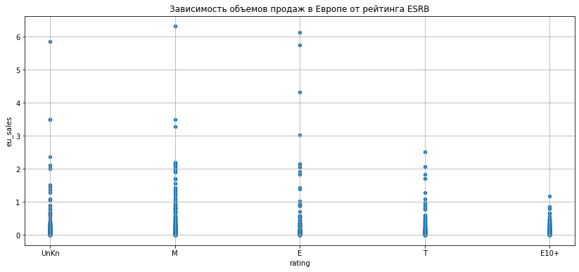

```python
data_new.plot(x = 'rating', y= 'eu_sales', kind = 'scatter', sharex=True, grid=True,\
                                     alpha= 1.0, figsize=(14, 6) )

plt.title('Зависимость объемов продаж в Европе от рейтинга ESRB');
```

- Исследуем регион NA, находим наиболее популярные платформы, жанры, также смотрим влияет ли рейтинг на объемы продаж за актуальный период

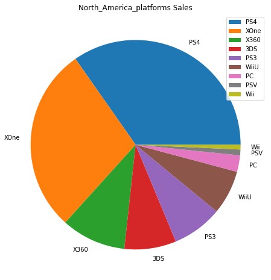

```python
# NA - platforms
na_platforms=data_new.pivot_table(index ='platform', values = 'na_sales', aggfunc='sum')
na_platforms=na_platforms.sort_values(by='na_sales', ascending=False)

na_platforms.plot(kind='pie', subplots=True, figsize=(8, 8))
plt.title("North_America_platforms Sales")
plt.ylabel("")
plt.show()
#display(na_platforms.head())
```

```python
# NA - genres
na_genre=data_new.pivot_table(index ='genre', values = 'na_sales', aggfunc='sum')
na_genre=na_genre.sort_values(by='na_sales', ascending=False)

display(na_genre.head())
```

| genre | na_sales |
| --- | --- |
| Shooter | 79.02 |
| Action | 72.53 |
| Sports | 46.13 |
| Role-Playing | 33.47 |
| Misc | 15.05 |

```python
# NA - rating
na_rating =data_new.pivot_table(index ='rating', values = 'na_sales', aggfunc='sum')
na_rating =na_rating.sort_values(by='na_sales', ascending=False)

display(na_rating.head())
```

| rating | na_sales |
| --- | --- |
| M | 96.42 |
| UnKn | 64.72 |
| E | 50.74 |
| T | 38.95 |
| E10+ | 33.23 |

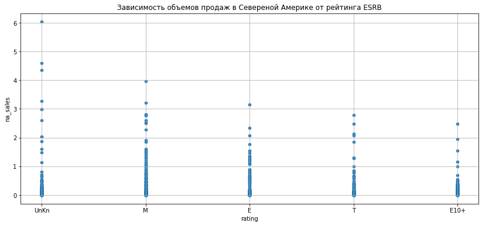

```python
data_new.plot(x = 'rating', y= 'na_sales', kind = 'scatter', sharex=True, grid=True,\
                                     alpha= 1.0, figsize=(14, 6) )

plt.title('Зависимость объемов продаж в Севереной Америке от рейтинга ESRB');
```

- Исследуем регион JP, находим наиболее популярные платформы, жанры, также смотрим влияет ли рейтинг на объемы продаж

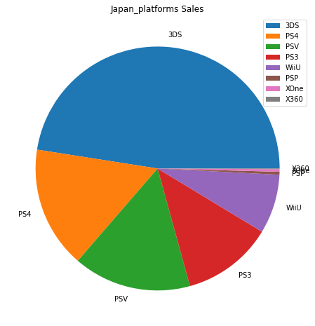

```python
# JP - platforms
jp_platforms=data_new.pivot_table(index ='platform', values = 'jp_sales', aggfunc='sum')
jp_platforms=jp_platforms.sort_values(by='jp_sales', ascending=False)

jp_platforms.plot(kind='pie', subplots=True, figsize=(8, 8))
plt.title("Japan_platforms Sales")
plt.ylabel("")
plt.show()

#display(jp_platforms.head())
```

```python
# JP - genres
jp_genre=data_new.pivot_table(index ='genre', values = 'jp_sales', aggfunc='sum')
jp_genre=jp_genre.sort_values(by='jp_sales', ascending=False)

display(jp_genre.head())
```

| genre | jp_sales |
| --- | --- |
| Role-Playing | 31.16 |
| Action | 29.58 |
| Fighting | 6.37 |
| Misc | 5.61 |
| Shooter | 4.87 |

```python
# JP - rating
jp_rating = data_new.pivot_table(index ='rating', values = 'jp_sales', aggfunc='sum')
jp_rating = jp_rating.sort_values(by='jp_sales', ascending=False)

display(jp_rating.head())
```

| rating | jp_sales |
| --- | --- |
| UnKn | 56.90 |
| T | 14.78 |
| E | 8.94 |
| M | 8.01 |
| E10+ | 4.46 |

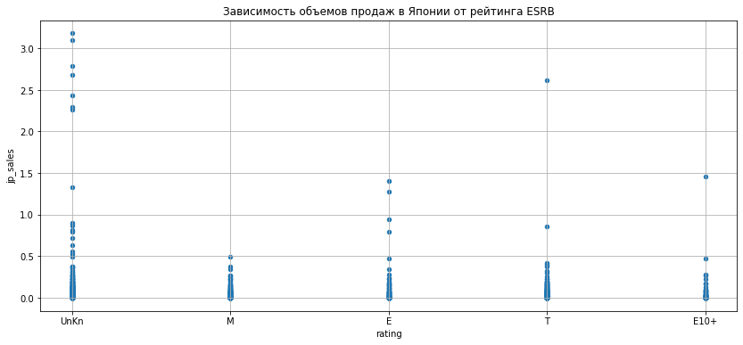

```python
data_new.plot(x = 'rating', y= 'jp_sales', kind = 'scatter', sharex=True, grid=True,\
                                     alpha= 1.0, figsize=(14, 6) )

plt.title('Зависимость объемов продаж в Японии от рейтинга ESRB');
```

Вывод: Предпочтения в регионах EU и NA примерно одинаковые. Самые популярные платформы PS4, XOne и также схожи по популярности жанры Action, Sport, Shooter. В Японии другая картина, явный лидер продаж 3DS потом идет платформа PS4, жанры - Role-playing, Action, Fighting. Рейтинг ESRB имеет большее влияние на продажи в Европе и СА, в то время как в Японии наибольшие продажи у платформ без рейтинга, также важно отметить, что вторая позиция в данном исследовании занимают платоформы без рейтинга, что указывает в целом на определенную относительность данной зависимости по регионам.

[output not shown]

# 5. Проверка гипотез

- Проверяем гипотезу, что средние пользовательские рейтинги платформ Xbox One и PC равны между собой, за актуальный период

```python
# создаем фильтр и находим значения пользовательского рейтинга для полатформ XOne и PC из общей выборки данных:
# удаляем NaN значения из оценки рейтинга пользователей
data_new = data_new.dropna(subset=['user_score'])

xone_rating_mean= data_new.query('platform == "XOne"')['user_score'].mean()
pc_rating_mean= data_new.query('platform == "PC"')['user_score'].mean()


print(xone_rating_mean)
print(pc_rating_mean)
```

```
6.594545454545456
6.298360655737705
```

Принимаем нулевую гипотезу Н0 - средние рейтинги Xbox One и PC равны. Альтернативная гипотеза рейтинги не равны. Находим либо подтвреждение ли опровержение принятой нулевой гипотезы:

```python
xone_rating= data_new.query('platform == "XOne"')['user_score'].to_list()
pc_rating= data_new.query('platform == "PC"')['user_score'].to_list()


alpha = 0.05 # критический уровень статистической значимости
# если p-value окажется меньше него - отвергнем гипотезу

results = st.ttest_ind(xone_rating,
                       pc_rating)
#print(results.pvalue)

print('p-значение:', results.pvalue)


if results.pvalue < alpha:
      print("Отвергаем нулевую гипотезу")
else:

      print("Не получилось отвергнуть нулевую гипотезу")
```

```
p-значение: 0.10450507919348415
Не получилось отвергнуть нулевую гипотезу
```

**Комментарий ревьюера 2 ⚠️** Правильно будет написать, что мы не можем отвергнуть нулевую гипотезу. У нас нет оснований утверждать, что средние пользовательские рейтинги платформ Xbox One и PC значимо различаются. В конце статьи про это хорошо написано: https://allatambov.github.io/psms/pdf/hypo-test.pdf

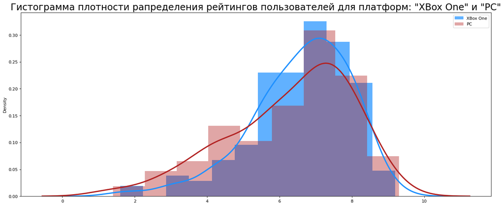

```python
### строим гистограмму для визуализации проведенного исследования:
plt.figure(figsize=(20,8), dpi= 80)
sns.distplot(xone_rating, color="dodgerblue", label="XBox One", hist_kws={'alpha':.7}, kde_kws={'linewidth':3})
sns.distplot(pc_rating, color="firebrick", label="PC", hist_kws={'alpha':.4}, kde_kws={'linewidth':3})

plt.title('Гистограмма плотности рапределения рейтингов пользователей для платформ: "XBox One" и "PC"', fontsize=22)
plt.legend()
plt.show()
warnings.filterwarnings("ignore")
```

Гистограмма подтверждает результат проведенного исследования

- Проверяем гипотезу, что средние пользовательские рейтинги жанров Action и Sports не равны между собой

```python
# создаем фильтр и находим значения пользовательского рейтинга жанров Action и Sports из общей выборки данных:
action_rating_mean= data_new.query('genre == "Action"')['user_score'].mean()
sports_rating_mean= data_new.query('genre == "Sports"')['user_score'].mean()

print(action_rating_mean)
print(sports_rating_mean)
```

```
6.760606060606061
5.2251968503937
```

Принимаем нулевую гипотезу Н0 - средние рейтинги Action и Sports равны. Альтернативная гипотеза рейтинги не равны. Находим либо подтвреждение ли опровержение принятой нулевой гипотезы:

```python
action_rating= data_new.query('genre == "Action"')['user_score'].to_list()
sports_rating= data_new.query('genre == "Sports"')['user_score'].to_list()

alpha = 0.05 # критический уровень статистической значимости
# если p-value окажется меньше него - отвергнем гипотезу

results = st.ttest_ind(action_rating,
                       sports_rating)
#print(results.pvalue)

print('p-значение:', results.pvalue)


if results.pvalue < alpha:
      print("Отвергаем нулевую гипотезу")
else:

      print("Не получилось отвергнуть нулевую гипотезу")
```

```
p-значение: 2.8711147985105864e-19
Отвергаем нулевую гипотезу
```

Значение p-value - меньше уровня статистической значимости в 5%. Отвергаем нулевую гипотезу - средние значения рейтингов жанров Action и Sports не равны между собой. Гипотеза (предположение), что средние рейтинги этих жанров разные, оказалось верным.

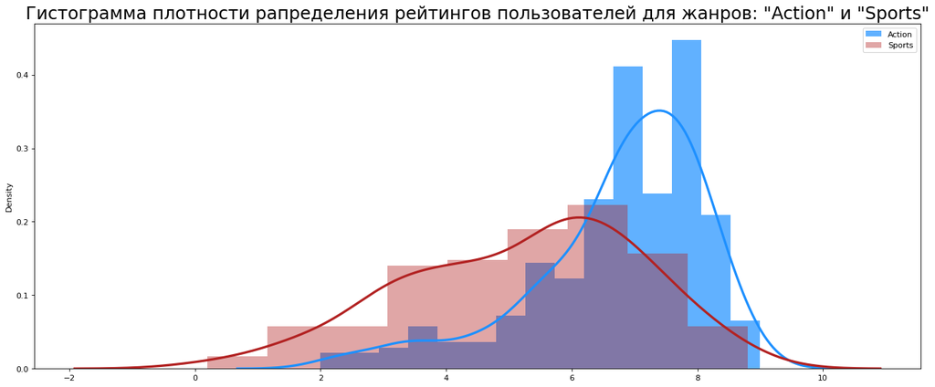

```python
### строим гистограмму для визуализации полученного вывода:
plt.figure(figsize=(20,8), dpi= 80)
sns.distplot(action_rating, color="dodgerblue", label="Action", hist_kws={'alpha':.7}, kde_kws={'linewidth':3})
sns.distplot(sports_rating, color="firebrick", label="Sports", hist_kws={'alpha':.4}, kde_kws={'linewidth':3})

plt.title('Гистограмма плотности рапределения рейтингов пользователей для жанров: "Action" и "Sports"', fontsize=22)
plt.legend()
plt.show()
warnings.filterwarnings("ignore")
```

На гистограмме видно, что кривые распределения плотности сильно отличаются, средний рейтинг пользователей игр с жанром Action выше рейтинга жанра Sports.

# 6. Общий вывод

[output not shown]